# what-s-this-chai-and-datascience

Solving the Mystery of Chai Time Data Science

A Data Science podcast series by Sanyam Bhutani

[figure not shown]

Mr. RsTaK, Where are we?

Hello my dear Kagglers. As you all know I love Kaggle and its community. I spend most of my time surfing my Kaggle feed, scrolling over discussion forms, appreciating the efforts put on by various Kagglers via their unique / interesting way of Storytelling.  
So, this morning when i was following my usual routine in Kaggle, I came across this Dataset named [Chai Time Data Science | CTDS.Show](https://www.kaggle.com/rohanrao/chai-time-data-science) provided by Mr. [Vopani](https://www.kaggle.com/rohanrao) and Mr. [Sanyam Bhutani](https://www.kaggle.com/init27). At first glance, I was like what's this? How they know I'm having a tea break? Oh no buddy! I was wrong. It's [CTDS.Show](https://chaitimedatascience.com) :)

Chai Time Data Science (CTDS.Show)

[figure not shown]

Chai Time Data Science show is a [Podcast](https://anchor.fm/chaitimedatascience) + [Video](https://www.youtube.com/playlist?list=PLLvvXm0q8zUbiNdoIazGzlENMXvZ9bd3x) + [Blog](https://sanyambhutani.com/tag/chaitimedatascience/) based show for interviews with Practitioners, Kagglers & Researchers and all things Data Science.

[CTDS.Show](https://chaitimedatascience.com), driven by the community under the supervision of Mr. [Sanyam Bhutani](https://www.kaggle.com/init27) gonna complete its 1 year anniversary on **21st June, 2020** and to celebrate this achievement they decided to run a **Kaggle contest** around the dataset with all of the **75+ ML Hero interviews** on the series.

We have our Dataset containing :

- **Description.csv** : This file consists of the **descriptions texts** from YouTube and Audio
- **Episodes.csv** : This file contains the **statistics of all the Episodes** of the Chai Time Data Science show.
- **YouTube Thumbnail Types.csv** : This file consists of the **description of Anchor/Audio thumbnail of the episodes**
- **Anchor Thumbnail Types.csv** : This file contains the **statistics of the Anchor/Audio thumbnail**
- **Raw Subtitles** : Directory containing **74 text files** having raw subtitles of all the episodes
- **Cleaned Subtitles** : Directory containing cleaned subtitles (in CSV format)

Hmm.. Seems we have some stories to talk about..

Congratulating [CTDS.Show](https://chaitimedatascience.com) for their **1 year anniversary**, Let's get it started :)

**0. Importing Necessary Libraries**

**1. A Closer look to our Dataset**

**1.1. Exploring YouTube Thumbnail Types.csv**  
**1.2. Exploring Anchor Thumbnail Types.csv**  
**1.3. Exploring Description.csv**  
**1.4. Exploring Episodes.csv**

**1.4.1. Missing Values ?**  
**1.4.2. M0-M8 Episodes**  
**1.4.3. Solving the Mystery of Missing Values**  
**1.4.4. Is it a Gender Biased Show?**  
**1.4.5. Time for a Chai Break**  
**1.4.6. How to get More Audience?**  
**1.4.7. Youtube Favors CTDS?**  
**1.4.8. Do Thumbnails really matter?**  
**1.4.9. How much Viewers wanna watch?**  
**1.4.10. Performance on Other Platforms**  
**1.4.11. Distribution of Heores by Country and Nationality**  
**1.4.12. Any Relation between Release Date of Epiosdes?**  
**1.4.13. Do I know about Release of anniversary interview episode?**

**1.5. Exploring Raw / Cleaned Substitles**  
**1.5.1. A Small Shoutout to Ramshankar Yadhunath**  
**1.5.2. Intro is Bad for CTDS ?**  
**1.5.3. Who Speaks More ?**  
**1.5.4. Frequency of Questions Per Episode**  
**1.5.5. Favourite Text ?**

**2. End Notes**

**3. Credits**

**Note :** Sometimes, Plotly Graphs fails to render with the Kernel. Please restart the page in that case

**Importing Necessary Libraries**

Go back to our Guide

```python
import os

import warnings
warnings.simplefilter("ignore")
warnings.filterwarnings("ignore", category=DeprecationWarning)

import numpy as np
import pandas as pd
import matplotlib.pyplot as plt

import missingno as msno

import plotly.express as px

import plotly.graph_objects as go
from plotly.subplots import make_subplots

!pip install pywaffle
from pywaffle import Waffle

from bokeh.layouts import column, row
from bokeh.models.tools import HoverTool
from bokeh.models import ColumnDataSource, Whisker
from bokeh.plotting import figure, output_notebook, show

output_notebook()

from IPython.display import IFrame

pd.set_option('display.max_columns', None)
```

```
     |████████████████████████████████| 525 kB 5.1 MB/s
```

**A Closer look to our Directories**

Go back to our Guide

Let's dive into each and every aspect of our Dataset step by step in order to get every inches out of it...

**Exploring YouTube Thumbnail Types.csv**

Go back to our Guide

```python
YouTube_df=pd.read_csv("../input/chai-time-data-science/YouTube Thumbnail Types.csv")
print("No of Datapoints : {}\nNo of Features : {}".format(YouTube_df.shape[0], YouTube_df.shape[1]))
YouTube_df.head()
```

```
No of Datapoints : 4
No of Features : 6
```

|  | youtube_thumbnail_type | description | youtube_default | annotation | mini_series | ctds_brand |
| --- | --- | --- | --- | --- | --- | --- |
| 0 | 0 | YouTube default image | 1 | 0 | 0 | 0 |
| 1 | 1 | YouTube default image with custom annotation | 1 | 1 | 0 | 0 |
| 2 | 2 | Mini Series: Custom Image with annotations | 0 | 1 | 1 | 0 |
| 3 | 3 | Custom image with CTDS branding, Title and Tags | 0 | 1 | 0 | 1 |

So, Basically [CTDS](https://chaitimedatascience.com) uses **4 types of Thumbnails** in their Youtube videos. Its 2020 and people still uses YouTube default image as thumbnail !

Hmm... a Smart decision or just a blind arrow, We'll figure it out in our futher analysis ...

**Exploring Anchor Thumbnail Types.csv**

Go back to our Guide

So, This file contains the statistics of the Anchor/Audio thumbnail

```python
Anchor_df=pd.read_csv("../input/chai-time-data-science/Anchor Thumbnail Types.csv")
print("No of Datapoints : {}\nNo of Features : {}".format(Anchor_df.shape[0], Anchor_df.shape[1]))
Anchor_df.head()
```

```
No of Datapoints : 4
No of Features : 6
```

|  | anchor_thumbnail_type | description | same_as_youtube | title | episode_details | ctds_brand |
| --- | --- | --- | --- | --- | --- | --- |
| 0 | 0 | YouTube default playlist image | 1 | 0 | 0 | 0 |
| 1 | 1 | CTDS Branding | 1 | 0 | 0 | 0 |
| 2 | 2 | Mini Series: Custom Image with annotations | 1 | 1 | 1 | 0 |
| 3 | 3 | Custom image with CTDS branding, Title and Tags | 1 | 1 | 1 | 1 |

It's just similar to Youtube Thumbnail Types.

If you are wondering What's anchor then it's a free platform for podcast creation

```python
IFrame('https://anchor.fm/chaitimedatascience', width=800, height=450)
```

[interactive chart not shown]

**Exploring Description.csv**

Go back to our Guide

This file consists of the descriptions texts from YouTube and Audio

```python
Des_df=pd.read_csv("../input/chai-time-data-science/Description.csv")
print("No of Datapoints : {}\nNo of Features : {}".format(Des_df.shape[0], Des_df.shape[1]))
Des_df.head()
```

```
No of Datapoints : 85
No of Features : 2
```

|  | episode_id | description |
| --- | --- | --- |
| 0 | E0 | Interview with ML Hero Series: https://medium.... |
| 1 | E1 | In the first Episode, Sanyam Bhutani interview... |
| 2 | E2 | Audio Version Available here: https://anchor.f... |
| 3 | E3 | Audio Version available here: https://anchor.f... |
| 4 | E4 | In this Conversation, Sanyam Bhutani interview... |

So, We have description for every episode. Let's have a close look what we have here

```python
def show_description(specific_id=None, top_des=None):

    if specific_id is not None:
        print(Des_df[Des_df.episode_id==specific_id].description.tolist()[0])

    if top_des is not None:
        for each_des in range(top_des):
            print(Des_df.description.tolist()[each_des])
            print("-"*100)
```

**⚒️ About the Function :**

In order to explore our Descriptions, I just wrote a small script. It has two options:

- Either You provide specific episode id(specific_id) to have a look at that particular description
- Or you can provide a number(top_des) and this script will display description for top "x" numbers that you provided in top_des

```python
show_description("E1")
```

```
In the first Episode, Sanyam Bhutani interviews Kaggle Triple Grandmaster: Abhishek Thakur. They talk about Abhishek's journey into Data Science and Kaggle; his Kaggle Experience and current projects.

Interview with Machine Learning Hero Series: https://medium.com/dsnet/interviews-with-machine-learning-heroes-ad9358385278

Follow:
Abhishek Thakur: https://www.kaggle.com/abhishek
https://www.linkedin.com/in/abhisvnit/
https://twitter.com/abhi1thakur

Sanyam Bhutani: https://twitter.com/bhutanisanyam1

About:
http://chaitimedatascience.com/
A show for Interviews with Practitioners, Kagglers & Researchers and all things Data Science hosted by Sanyam Bhutani.

You can expect weekly episodes every Sunday, Thursday available as Video, Podcast, and blogposts.

If you'd like to support the podcast: https://www.patreon.com/chaitimedatascience
Intro track:
Flow by LiQWYD https://soundcloud.com/liqwyd
```

```python
show_description(top_des=3)
```

```
Interview with ML Hero Series: https://medium.com/p/bfaaf38df219

http://chaitimedatascience.com/
A show for Interviews with Practitioners, Kagglers & Researchers and all things Data Science hosted by Sanyam Bhutani.

You can expect weekly episodes every Sunday, Thursday available as Video, Podcast, and blogpost.

Intro track:
Flow by LiQWYD https://soundcloud.com/liqwyd
----------------------------------------------------------------------------------------------------
In the first Episode, Sanyam Bhutani interviews Kaggle Triple Grandmaster: Abhishek Thakur. They talk about Abhishek's journey into Data Science and Kaggle; his Kaggle Experience and current projects.

Interview with Machine Learning Hero Series: https://medium.com/dsnet/interviews-with-machine-learning-heroes-ad9358385278

Follow:
Abhishek Thakur: https://www.kaggle.com/abhishek
https://www.linkedin.com/in/abhisvnit/
https://twitter.com/abhi1thakur

Sanyam Bhutani: https://twitter.com/bhutanisanyam1

About:
http://chaitimedatascience.com/
A show for Interviews with Practitioners, Kagglers & Researchers and all things Data Science hosted by Sanyam Bhutani.

You can expect weekly episodes every Sunday, Thursday available as Video, Podcast, and blogposts.

If you'd like to support the podcast: https://www.patreon.com/chaitimedatascience
Intro track:
Flow by LiQWYD https://soundcloud.com/liqwyd
----------------------------------------------------------------------------------------------------
Audio Version Available here: https://anchor.fm/chaitimedatascience

In this Episode, Sanyam Bhutani interviews Kaggle Competition Master: Ryan Chesler. They talk about Ryan's journey into Data Science and Kaggle; his Kaggle Experience and current projects as well as his solution to the Jigsaw Unintended Bias in Toxicity Classification Kaggle Competition

Interview with Machine Learning Hero Series: https://medium.com/dsnet/interviews-with-machine-learning-heroes-ad9358385278

Follow:
Ryan Chesler: https://www.kaggle.com/ryches
https://www.linkedin.com/in/ryan-chesler/
https://twitter.com/ryan_chesler

Sanyam Bhutani: https://twitter.com/bhutanisanyam1

About:
http://chaitimedatascience.com/
A show for Interviews with Practitioners, Kagglers & Researchers and all things Data Science hosted by Sanyam Bhutani.

You can expect weekly episodes every Sunday, Thursday available as Video, Podcast, and blogposts.

If you'd like to support the podcast: https://www.patreon.com/chaitimedatascience
Intro track:
Flow by LiQWYD https://soundcloud.com/liqwyd
----------------------------------------------------------------------------------------------------
```

**Advice :** Feel free to play with the function "show_description()" to have a look over various descriptions provided in a go

**🧠 My Cessation:**

- Although I went through some description and realized it just contains **URL**, **Necessary links** for social media sites with a **little description** of the current show and some **announcements regarding future releases**
- I'm **not gonna put stress** in this area because **I don't think there's much to scrap in them**. Right now, let's move ahead.

**Exploring Episodes.csv**

Go back to our Guide

This file contains the statistics of all the Episodes of the Chai Time Data Science show.

Okay ! So, it's the big boy itself ..

```python
Episode_df=pd.read_csv("../input/chai-time-data-science/Episodes.csv")
print("No of Datapoints : {}\nNo of Features : {}".format(Episode_df.shape[0], Episode_df.shape[1]))
Episode_df.head()
```

```
No of Datapoints : 85
No of Features : 36
```

|  | episode_id | episode_name | heroes | heroes_gender | heroes_location | heroes_nationality | heroes_kaggle_username | heroes_twitter_handle | category | flavour_of_tea | recording_date | recording_time | release_date | episode_duration | youtube_url | youtube_thumbnail_type | youtube_impressions | youtube_impression_views | youtube_ctr | youtube_nonimpression_views | youtube_views | youtube_watch_hours | youtube_avg_watch_duration | youtube_likes | youtube_dislikes | youtube_comments | youtube_subscribers | anchor_url | anchor_thumbnail_type | … |
| --- | --- | --- | --- | --- | --- | --- | --- | --- | --- | --- | --- | --- | --- | --- | --- | --- | --- | --- | --- | --- | --- | --- | --- | --- | --- | --- | --- | --- | --- | --- |
| 0 | E0 | Chai Time Data Science Launch Announcement | NaN | NaN | NaN | NaN | NaN | NaN | Other | Masala Chai | 2019-07-15 | Evening | 2019-07-21 | 157 | https://www.youtube.com/watch?v=Ko_gxs42lM8 | 1 | 4433 | 86 | 1.94 | 45 | 131 | 3 | 82 | 4 | 0 | 2 | 3 | https://anchor.fm/chaitimedatascience/episodes... | 0.0 | … |
| 1 | E1 | Kaggle Triple Grandmaster, Abhishek Thakur Int... | Abhishek Thakur | Male | Norway | India | abhishek | abhi1thakur | Kaggle | Ginger Chai | 2019-07-14 | Evening | 2019-07-22 | 2995 | https://www.youtube.com/watch?v=Ezbo57Z33N8 | 0 | 25212 | 845 | 3.35 | 683 | 1528 | 142 | 335 | 55 | 0 | 5 | 60 | https://anchor.fm/chaitimedatascience/episodes... | 0.0 | … |
| 2 | E2 | Interview with Kaggle Master, ML Engineer: Rya... | Ryan Chesler | Male | USA | USA | ryches | ryan_chesler | Kaggle | Masala Chai | 2019-07-20 | Afternoon | 2019-07-26 | 2118 | https://www.youtube.com/watch?v=SJVMSKig14k | 0 | 3282 | 84 | 2.56 | 44 | 128 | 14 | 394 | 7 | 0 | 1 | 3 | https://anchor.fm/chaitimedatascience/episodes... | 0.0 | … |
| 3 | E3 | Interview with CEO of SharpestMinds, Edouard H... | Edouard Harris | Male | Canada | Canada | NaN | neutronsNeurons | Industry | Kashmiri Kahwa | 2019-07-23 | Night | 2019-07-29 | 3072 | https://www.youtube.com/watch?v=69urmSt34Ac | 0 | 2376 | 38 | 1.60 | 57 | 95 | 11 | 417 | 2 | 0 | 0 | 1 | https://anchor.fm/chaitimedatascience/episodes... | 0.0 | … |
| 4 | E4 | Data Science for Good: City of LA Kaggle Winni... | Shivam Bansal | Male | Singapore | India | shivamb | shivamshaz | Kaggle | Apple Cinnamon | 2019-07-14 | Morning | 2019-08-02 | 1048 | https://www.youtube.com/watch?v=wMYX3KABHCk | 0 | 3884 | 116 | 2.99 | 36 | 152 | 9 | 213 | 4 | 0 | 0 | 4 | https://anchor.fm/chaitimedatascience/episodes... | 0.0 | … |

Wew ! That's a lot of features.

I'm sure We'll gonna explore some interesting insights from this Metadata If you reached till here, then please bare me for couple of minutes more..  
Now, We'll gonna have a big sip of our "Chai" :)

[figure not shown]

**Missing Values**

Before diving into our analysis, Let's have check for Missing Values in our CSV..

For this purpose, I'm gonna use this library named missingno.

Just use this line :

> import missingno as msno

missingno helps us to deal with missing values in a dataset with the help of visualisations. With over 2k stars on github, this library is already very popular.

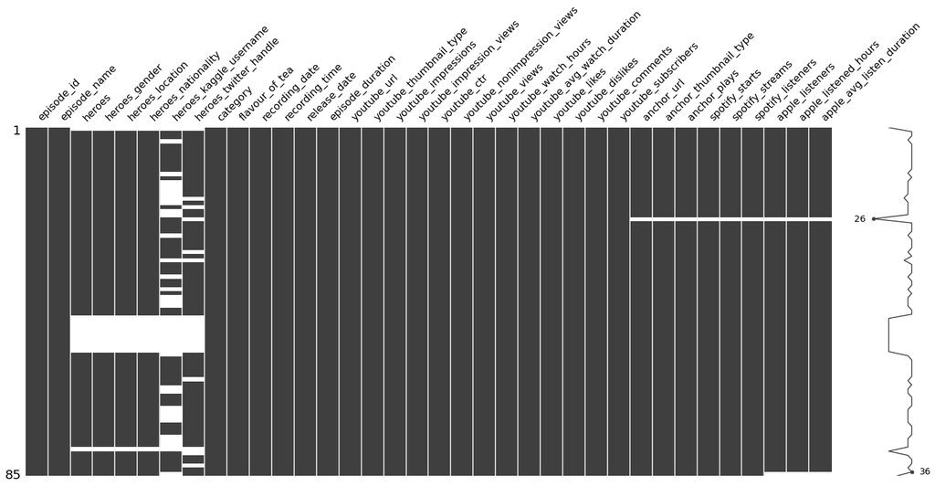

```python
msno.matrix(Episode_df)
```

Aah shit ! Here We go again..

[figure not shown]

**📌 Observations :**

- We can clearly see that **heroes_kaggle_username**, **heroes_twitter_handle** have **lots of missing values**
- We can observe **bunch of data missing** from column name **heroes to heroes_twitter_handle** in a **continous way(that big block region)** which shows a **specific reason** of data missing at those points
- **Few datapoints** are too **missing** in **anchor**, **spotify** and **apple** section i.e. missing data in **podcasts**

There is also a chart on the right side of plot.It summarizes the general shape of the data completeness and points out the rows with the maximum and minimum nullity in the dataset.

Well, Before giving any False Proclaim Let's explore more about it..

```python
temp=Episode_df.isnull().sum().reset_index().rename(columns={"index": "Name", 0: "Count"})
temp=temp[temp.Count!=0]

Source=ColumnDataSource(temp)

tooltips = [

    ("Feature Name", "@Name"),
    ("No of Missing entites", "@Count")
]

fig1 = figure(background_fill_color="#ebf4f6", plot_width = 600, plot_height = 400,tooltips=tooltips, x_range = temp["Name"].values, title = "Count of Missing Values")
fig1.vbar("Name", top = "Count", source = Source, width = 0.4, color = "#76b4bd", alpha=.8)

fig1.xaxis.major_label_orientation = np.pi / 8
fig1.xaxis.axis_label = "Features"
fig1.yaxis.axis_label = "Count"

fig1.grid.grid_line_color="#feffff"


show(fig1)
```

[interactive chart not shown]

**📌 Observations :**

- Columns from **heroes** to **heroes_nationality** has same about of missing data. Seems We can find a **reasonable relation** between them
- About **45.88% (85-39)** and **22.35% (85-19)** of Data missing in column name **heroes_kaggle_username** and **heroes_twitter_handle** respectively
- We have just **1 missing value** in **anchor** and **spotify**, **2 missing values** in **apple section** that is quite easy to handle

**🧠 My Cessation:**

- Come-on. I don't understand. Chai Time Data Science show is about interviews with our Heroes. So, How do we have **11 missing values in Feature "heroes"**

[figure not shown]

Let's find out..

```python
Episode_df[Episode_df.heroes.isnull()]
```

|  | episode_id | episode_name | heroes | heroes_gender | heroes_location | heroes_nationality | heroes_kaggle_username | heroes_twitter_handle | category | flavour_of_tea | recording_date | recording_time | release_date | episode_duration | youtube_url | youtube_thumbnail_type | youtube_impressions | youtube_impression_views | youtube_ctr | youtube_nonimpression_views | youtube_views | youtube_watch_hours | youtube_avg_watch_duration | youtube_likes | youtube_dislikes | youtube_comments | youtube_subscribers | anchor_url | anchor_thumbnail_type | … |
| --- | --- | --- | --- | --- | --- | --- | --- | --- | --- | --- | --- | --- | --- | --- | --- | --- | --- | --- | --- | --- | --- | --- | --- | --- | --- | --- | --- | --- | --- | --- |
| 0 | E0 | Chai Time Data Science Launch Announcement | NaN | NaN | NaN | NaN | NaN | NaN | Other | Masala Chai | 2019-07-15 | Evening | 2019-07-21 | 157 | https://www.youtube.com/watch?v=Ko_gxs42lM8 | 1 | 4433 | 86 | 1.94 | 45 | 131 | 3 | 82 | 4 | 0 | 2 | 3 | https://anchor.fm/chaitimedatascience/episodes... | 0.0 | … |
| 46 | M0 | 00 Introduction & About: fast.ai 2019 & Things... | NaN | NaN | NaN | NaN | NaN | NaN | Other | Kesar Rose Chai | 2020-02-26 | Night | 2020-03-07 | 624 | https://www.youtube.com/watch?v=rzuIkj8lymc | 2 | 3789 | 139 | 3.67 | 162 | 301 | 15 | 179 | 15 | 0 | 2 | 10 | https://anchor.fm/chaitimedatascience/episodes... | 2.0 | … |
| 47 | M1 | 01: Lesson-1 Image Classification \| fast.ai 20... | NaN | NaN | NaN | NaN | NaN | NaN | Other | Kesar Rose Chai | 2020-02-26 | Night | 2020-03-07 | 341 | https://www.youtube.com/watch?v=RKtfgXz7Qo0 | 2 | 4643 | 163 | 3.51 | 56 | 219 | 7 | 115 | 8 | 0 | 2 | 1 | https://anchor.fm/chaitimedatascience/episodes... | 2.0 | … |
| 48 | M2 | 02: Lesson-2 Production & SGD From Scratch \| f... | NaN | NaN | NaN | NaN | NaN | NaN | Other | Kesar Rose Chai | 2020-02-26 | Night | 2020-03-07 | 316 | https://www.youtube.com/watch?v=ahdybq2V-38 | 2 | 3144 | 63 | 2.00 | 37 | 100 | 3 | 108 | 2 | 1 | 0 | 0 | https://anchor.fm/chaitimedatascience/episodes... | 2.0 | … |
| 49 | M3 | 03: Lesson-3 Multi-label; SGD from scratch \| f... | NaN | NaN | NaN | NaN | NaN | NaN | Other | Kesar Rose Chai | 2020-02-26 | Night | 2020-03-07 | 332 | https://www.youtube.com/watch?v=Z-waVKLcLJE | 2 | 2436 | 52 | 2.13 | 28 | 80 | 3 | 135 | 2 | 0 | 0 | 0 | https://anchor.fm/chaitimedatascience/episodes... | 2.0 | … |
| 50 | M4 | 04: Lesson-4 NLP:Tabular Data; Recsys \| fast.a... | NaN | NaN | NaN | NaN | NaN | NaN | Other | Kesar Rose Chai | 2020-02-26 | Night | 2020-03-07 | 281 | https://www.youtube.com/watch?v=5CW3QdGdr8c | 2 | 2592 | 40 | 1.54 | 23 | 63 | 2 | 114 | 3 | 0 | 0 | 1 | https://anchor.fm/chaitimedatascience/episodes... | 2.0 | … |
| 51 | M5 | 05: Lesson 5: Backprop; Neural Nets from scrat... | NaN | NaN | NaN | NaN | NaN | NaN | Other | Kesar Rose Chai | 2020-02-26 | Night | 2020-03-07 | 311 | https://www.youtube.com/watch?v=RIGlXwvUo_Q | 2 | 2536 | 26 | 1.03 | 11 | 37 | 1 | 97 | 0 | 0 | 0 | 0 | https://anchor.fm/chaitimedatascience/episodes... | 2.0 | … |
| 52 | M6 | 06: Lesson-6 CNN Deep Dive; Ethics \| fast.ai 2... | NaN | NaN | NaN | NaN | NaN | NaN | Other | Kesar Rose Chai | 2020-02-26 | Night | 2020-03-07 | 412 | https://www.youtube.com/watch?v=nAE8tq_SIXo | 2 | 3572 | 49 | 1.37 | 33 | 82 | 2 | 88 | 2 | 0 | 0 | 0 | https://anchor.fm/chaitimedatascience/episodes... | 2.0 | … |
| 53 | M7 | 07: Lesson-7 ResNet; U-Net; GANs \| fast.ai 201... | NaN | NaN | NaN | NaN | NaN | NaN | Other | Kesar Rose Chai | 2020-02-26 | Night | 2020-03-07 | 467 | https://www.youtube.com/watch?v=0eWG6apI1iY | 2 | 2381 | 22 | 0.92 | 20 | 42 | 2 | 171 | 1 | 0 | 0 | 0 | https://anchor.fm/chaitimedatascience/episodes... | 2.0 | … |
| 54 | M8 | 08: Where to go from here, General fast.ai advice | NaN | NaN | NaN | NaN | NaN | NaN | Other | Kesar Rose Chai | 2020-02-26 | Night | 2020-03-07 | 605 | https://www.youtube.com/watch?v=oOr-7hYaU8o | 2 | 2133 | 33 | 1.55 | 11 | 44 | 2 | 164 | 1 | 0 | 0 | 0 | https://anchor.fm/chaitimedatascience/episodes... | 2.0 | … |
| 78 | E69 | Birthday Special AMA: Answering Questions from... | NaN | NaN | NaN | NaN | NaN | NaN | Other | Masala Chai | 2020-05-27 | Morning | 2020-05-27 | 3984 | https://www.youtube.com/watch?v=hyJhwWshfbY | 3 | 3698 | 163 | 4.41 | 338 | 501 | 55 | 395 | 36 | 1 | 3 | 15 | https://anchor.fm/chaitimedatascience/episodes... | 3.0 | … |

**💭 Interesting..**

- episode_id "E0" was all about Chai Time Data Science Launch Announcement
- episode_id "E69" was Birthday Special It make sense why there's no hero for the following episodes

But What are these M0-M8 episodes .. ?

**M0-M8 Episodes**

- Looking around for a while, I realized M0-M8 was a small mini-series based on fast.ai summaries and the Things Jeremy says to do that were released on same date.

**🧠 My Cessation:**

- Well for the sake of our analysis, I'll treat them as outlier for the current CSV and will analyise them seperately. So, I'm gonna remove them from this CSV, storing seperately for later analysis

```python
temp=[id for id in Episode_df.episode_id if id.startswith('M')]
fastai_df=Episode_df[Episode_df.episode_id.isin(temp)]
Episode_df=Episode_df[~Episode_df.episode_id.isin(temp)]
```

Also, ignoring "E0" and "E69" for right now ...

```python
dummy_df=Episode_df[(Episode_df.episode_id!="E0") & (Episode_df.episode_id!="E69")]
```

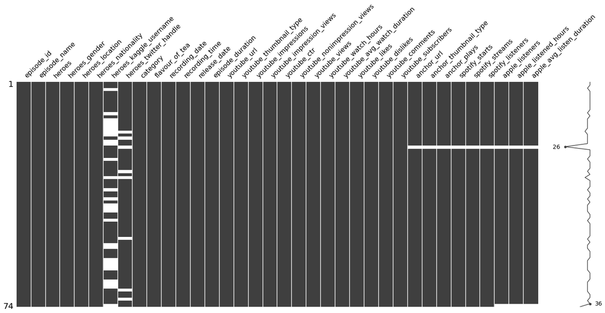

```python
msno.matrix(dummy_df)
```

```python
temp=dummy_df.isnull().sum().reset_index().rename(columns={"index": "Name", 0: "Count"})
temp=temp[temp.Count!=0]

Source=ColumnDataSource(temp)

tooltips = [
    ("Feature Name", "@Name"),
    ("No of Missing entites", "@Count")
]

fig1 = figure(background_fill_color="#ebf4f6", plot_width = 600, plot_height = 400,tooltips=tooltips, x_range = temp["Name"].values, title = "Count of Missing Values")
fig1.vbar("Name", top = "Count", source = Source, width = 0.4, color = "#76b4bd", alpha=.8)

fig1.xaxis.major_label_orientation = np.pi / 4
fig1.xaxis.axis_label = "Features"
fig1.yaxis.axis_label = "Count"

fig1.grid.grid_line_color="#feffff"

show(fig1)
```

[interactive chart not shown]

Now, That's much better..

But We still have a lots of Missing Values

**Solving the Mystery of Missing Values**

```python
parent=[]
names =[]
values=[]
temp=dummy_df.groupby(["category"]).heroes_gender.value_counts()
for k in temp.index:
    parent.append(k[0])
    names.append(k[1])
    values.append(temp.loc[k])

df1 = pd.DataFrame(
    dict(names=names, parents=parent,values=values))


parent=[]
names =[]
values=[]
temp=dummy_df.groupby(["category","heroes_gender"]).heroes_kaggle_username.count()
for k in temp.index:
    parent.append(k[0])
    names.append(k[1])
    values.append(temp.loc[k])

df2 = pd.DataFrame(
    dict(names=names, parents=parent,values=values))


fig = px.sunburst(df1, path=['names', 'parents'], values='values', color='parents',hover_data=["names"], title="Heroes associated with Categories")
fig.update_traces(
                 textinfo='percent entry+label',
                 hovertemplate = "Industry:%{label}: <br>Count: %{value}"
                )
fig.show()


fig = px.sunburst(df2, path=['names', 'parents'], values='values', color='parents', title="Heroes associated with Categories having Kaggle Account")
fig.update_traces(
                 textinfo='percent entry+label',
                 hovertemplate = "Industry:%{label}: <br>Count: %{value}"
                )
fig.show()
```

[interactive chart not shown]

**📌 Observations :**

- Heores associated with "Category" **Kaggle** are expected to have a **Kaggle account**
- Ignoring the counts from "Category" Kaggle (74-31=43), **Out of 43 only 15 Heroes have Kaggle account**.
- This **explains all Missing 28 Values** from our CSV
- Similarly We have **8 Heroes who don't have twitter handle**. It's okay. Even I don't have a twitter handle :D

**Wanna know a fun fact ?**

> Because of this Kaggle platform, Now I've aprox **42%** chance of becoming a CTDS Hero :) ...

[figure not shown]

Ahem Ahem... Focus [RsTaK](https://www.kaggle.com/rahulgulia) Focus.. Let's get back to our work.

Wait? Guess I missed something.. What's that gender ratio?

**Is it a Gender Biased Show?**

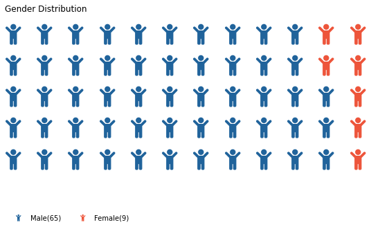

```python
gender = Episode_df.heroes_gender.value_counts()

fig = plt.figure(
    FigureClass=Waffle,
    rows=5,
    columns=12,
    values=gender,
    colors = ('#20639B', '#ED553B'),
    title={'label': 'Gender Distribution', 'loc': 'left'},
    labels=["{}({})".format(a, b) for a, b in zip(gender.index, gender) ],
    legend={'loc': 'lower left', 'bbox_to_anchor': (0, -0.4), 'ncol': len(Episode_df), 'framealpha': 0},
    font_size=30,
    icons = 'child',
    figsize=(12, 5),
    icon_legend=True
)
```

Jokes apart, We can't give any strong statement over this.

But yea, I'm hoping for more Female Heroes :D

**🧠 My Cessation:**

I won't talk much about relation of gender with other features because :

- Gender feature is highly biased towards one category

So, We can not conclude any relation with other features.

- If we had a good gender ratio, then we could have talked about impact of gender

Even if we somehow observe any positive conclusion for Female gender then I would say it will be just a coincidence. There are other factors apart from gender that may have resulted in positive conclusion for Female gender.

With such a biased and small sample size for Female, We can not comment any strong statement on that

```python
dummy_df[dummy_df.apple_listeners.isnull()]
```

|  | episode_id | episode_name | heroes | heroes_gender | heroes_location | heroes_nationality | heroes_kaggle_username | heroes_twitter_handle | category | flavour_of_tea | recording_date | recording_time | release_date | episode_duration | youtube_url | youtube_thumbnail_type | youtube_impressions | youtube_impression_views | youtube_ctr | youtube_nonimpression_views | youtube_views | youtube_watch_hours | youtube_avg_watch_duration | youtube_likes | youtube_dislikes | youtube_comments | youtube_subscribers | anchor_url | anchor_thumbnail_type | … |
| --- | --- | --- | --- | --- | --- | --- | --- | --- | --- | --- | --- | --- | --- | --- | --- | --- | --- | --- | --- | --- | --- | --- | --- | --- | --- | --- | --- | --- | --- | --- |
| 22 | E12 | Freelancing in Machine Learning \| Interview wi... | Tuatini Godard | Male | France | France | ekami66 | NaN | Industry | Kashmiri Kahwa | 2019-07-11 | Morning | 2019-10-29 | 2684 | https://www.youtube.com/watch?v=AwJpKBMog6c | 0 | 3659 | 61 | 1.67 | 53 | 114 | 17 | 537 | 4 | 0 | 0 | 2 | NaN | NaN | … |
| 84 | E75 | Rachel Thomas \| Fast.ai \| Applied Ethics \| Top... | Rachel Thomas | Female | USA | USA | NaN | math_rachel | Industry | Masala Chai | 2020-06-16 | Night | 2020-06-18 | 2214 | https://www.youtube.com/watch?v=tq_XcFubgKo&li... | 3 | 1931 | 115 | 5.96 | 164 | 279 | 23 | 297 | 20 | 0 | 1 | 3 | https://anchor.fm/chaitimedatascience/episodes... | 3.0 | … |

**📌 Observations :**

Following our analysis, We realized :

- CTDS had an episode with **Tuatini Godard, episode_id : "E12" exclusively for Youtube**. Although it was an **Audio Only video**(if it makes sense :D ) released on Youtube
- If it was an Audio Only Version, then **Why it wasn't released on other platforms** ? Hmmm... interesting. Well, I think Mr. [Sanyam Bhutani](https://www.kaggle.com/init27) can answer this well.
- Similarly, CTDS had an **episode with Rachel Thomas released at every platform expect for Apple**

With this, We have solved all the mysteries related to the Missing Data. Now we can finally explore other aspects of this CSV

But before that..

**Time for a Chai Break**

[figure not shown]

While having a sip of my Chai (Tea), I'm just curious **Why this show is named "Chai Time Data Science"?**  
Well, I **don't have a solid answer** for this but maybe its just **because our Host loves Chai?** Hmmm.. So You wanna say our Host is more Hardcore Chai Lover than me?

Hey ! Hold my Chai..

```python
fig = go.Figure([go.Pie(labels=Episode_df.flavour_of_tea.value_counts().index.to_list(),values=Episode_df.flavour_of_tea.value_counts().values,hovertemplate = '<br>Type: %{label}</br>Count: %{value}<br>Popularity: %{percent}</br>', name = '')])
fig.update_layout(title_text="What Host drinks everytime ?", template="plotly_white", title_x=0.45, title_y = 1)
fig.data[0].marker.line.color = 'rgb(255, 255, 255)'
fig.data[0].marker.line.width = 2
fig.update_traces(hole=.4,)
fig.show()
```

[interactive chart not shown]

**📌 Observations :**

- **Masala Chai (count=16)** and **Ginger Chai (count=16)** seems to be **favourite Chai** of our Host **followed by Herbal Tea (count=11) and Sulemani Chai (count=11)**
- Also, Our Host seems to be **quite experimental with Chai**. He has varities of flavour in his belly

Oh Man ! This time you win. You're a real Chai lover

**Now, One Question arises..❓**

**So, Host drinking any specific Chai at specific time have any relation with other factors or success of CTDS?**

**🧠 My Cessation:**

- Thinking practically, **I don't think** drinking Chai at any specific time can have **any real impact** for the show.
- Believing on such things is an **example of superstition**.
- No doubt, as per the data it **may have some relation** with other factors. But to support any statement here, I would like to quote a **famous sentence used in statistics** i.e.

[figure not shown]

**Correlation** does not imply **Causation**

**How to get More Audience?**

Well, rewarding for your victory in that Chai Lover Challenge, I'll try to assist CTDS on how to get more Audience 😄

- Ofcourse CTDS.Shows are a kind of gem, fully informative, covering interviews with some successfull people
- But talking Statistically here, We'll gonna define Success of an Episode by amount of Audience it gathered

```python
temp=dummy_df.isnull().sum().reset_index().rename(columns={"index": "Name", 0: "Count"})
temp=temp[temp.Count!=0]

Source=ColumnDataSource(temp)

tooltips = [
    ("Feature Name", "@Name"),
    ("No of Missing entites", "@Count")
]

fig1 = figure(background_fill_color="#ebf4f6", plot_width = 600, plot_height = 400,tooltips=tooltips, x_range = temp["Name"].values, title = "Count of Missing Values")
fig1.vbar("Name", top = "Count", source = Source, width = 0.4, color = "#76b4bd", alpha=.8)

fig1.xaxis.major_label_orientation = np.pi / 4
fig1.xaxis.axis_label = "Features"
fig1.yaxis.axis_label = "Count"

fig1.grid.grid_line_color="#feffff"

show(fig1)
```

[interactive chart not shown]

```python
Episode_df.release_date = pd.to_datetime(Episode_df.release_date)
Source = ColumnDataSource(Episode_df)
fastai_df.release_date = pd.to_datetime(fastai_df.release_date)
Source2 = ColumnDataSource(fastai_df)

tooltips = [
    ("Episode Id", "@episode_id"),
    ("Episode Title", "@episode_name"),
    ("Hero Present", "@heroes"),
    ("CTR", "@youtube_ctr"),
    ("Category", "@category"),
    ("Date", "@release_date{%F}"),
    ]

tooltips2 = [
    ("Episode Id", "@episode_id"),
    ("Episode Title", "@episode_name"),
    ("Hero Present", "@heroes"),
    ("Subscriber Gain", "@youtube_subscribers"),
    ("Category", "@category"),
    ("Date", "@release_date{%F}"),
    ]


fig1 = figure(background_fill_color="#ebf4f6",plot_width = 600, plot_height = 400, x_axis_type = "datetime", title = "CTR Per Episode")
fig1.line("release_date", "youtube_ctr", source = Source, color = "#03c2fc", alpha = 0.8, legend_label="youtube_ctr")
fig1.varea(source=Source, x="release_date", y1=0, y2="youtube_ctr", alpha=0.2, fill_color='#55FF88', legend_label="youtube_ctr")
fig1.line("release_date", Episode_df.youtube_ctr.mean(), source = Source, color = "#f2a652", alpha = 0.8,line_dash="dashed", legend_label="Youtube CTR Mean : {:.3f}".format(Episode_df.youtube_ctr.mean()))
fig1.circle(x="release_date", y="youtube_ctr", source = Source2, color = "#5bab37", alpha = 0.8, legend_label="M0-M8 Series")

fig1.add_tools(HoverTool(tooltips=tooltips,formatters={"@release_date": "datetime"}))
fig1.xaxis.axis_label = "Release Date"
fig1.yaxis.axis_label = "Click Per Impression"

fig1.grid.grid_line_color="#feffff"

fig2 = figure(background_fill_color="#ebf4f6", plot_width = 600, plot_height = 400, x_axis_type = "datetime", title = "Subscriber Gain Per Episode")
fig2.line("release_date", "youtube_subscribers", source = Source, color = "#03c2fc", alpha = 0.8, legend_label="Subscribers")
fig2.varea(source=Source, x="release_date", y1=0, y2="youtube_subscribers", alpha=0.2, fill_color='#55FF88', legend_label="Subscribers")
fig2.circle(x="release_date", y="youtube_subscribers", source = Source2, color = "#5bab37", alpha = 0.8, legend_label="M0-M8 Series")


fig2.add_tools(HoverTool(tooltips=tooltips2,formatters={"@release_date": "datetime"}))
fig2.xaxis.axis_label = "Release Date"
fig2.yaxis.axis_label = "Subscriber Count"

fig2.grid.grid_line_color="#feffff"

show(column(fig1, fig2))
```

[interactive chart not shown]

**📌 Observations :**

From the Graphs, We can see :

- On an average, CTDS episodes had **2.702 CTR**
- **38 out of 76 (50% exact)** have CTRs above the average
- Episode **E1, E27 and E49 seems to be lucky** for CTDS in terms of **Subscriber Count**
- Episode E19 had the **best CTR (8.460)** which is self explanatory from the Episode Title. Everyone loves to know about MOOC(s) and ML Interviews in Industries

**🤖 M0-M8 Series :**

**💭 Interestingly..**,

- Episode **E19 despite of having best CTR** till now (8.460), **didn't contributed much** in Subscriber Count (only 7 Subscriber Gained)

But Why ❓

- CTR **doen't mean that person likes the content**, or **he/she will be watching that video** for long or will be **subscribing to the channel**
- Maybe that video was **recommended on his newsfeed and he/she clicked on it** just to check the video
- Maybe he/she **doesn't liked the content**
- Maybe he/she **accidently clicked** on the video

There's an huge possibility of such cases. But in conclusion, We can say high CTR reflect cases like :

- People clicked on the video maybe because of the **Thumbnail, or Title was soothing**. Maybe he/she clicked because of the **hero mentioned in Title/Thumbnail**

📃 I don't know how Youtube algorithm works. But for the sake of answering exceptional case of E19, My hypothetical answer will be:

- Title contains the word **"MOOC"**. Since now a days everyone wanna **break into DataScience**, Youtube algorithm may have **suggested** that video to people looking for MOOCs
- Most of other episodes have similar kind of Titles stating **"Interview with"** or have some terms that **are't that begineer friendly**. Resulting in **low CTR**
- Supporting my hypothesis, observe **E27** (having fast.ai in Title that is a famous MOOC), **E38**(Title with Youngest Grandmaster may have attracted people to click),**E49** (Getting started in Datascience), **E60**(Terms like NLP and Open Source Projects) and **E75**(again fast.ai)
- You can **argue for E12** which has the word "Freelancing" in the Title. Well **exceptions** will be there

Okay What's about organic reach of channel or reach via Heroes?

```python
Source = ColumnDataSource(Episode_df)
Source2 = ColumnDataSource(fastai_df)

tooltips = [
    ("Episode Id", "@episode_id"),
    ("Hero Present", "@heroes"),
    ("Impression Views", "@youtube_impression_views"),
    ("Non Impression Views", "@youtube_nonimpression_views"),
    ("Category", "@category"),
    ("Date", "@release_date{%F}"),
    ]

tooltips2 = [
    ("Episode Id", "@episode_id"),
    ("Hero Present", "@heroes"),
    ("Subscriber Gain", "@youtube_subscribers"),
    ("Category", "@category"),
    ("Date", "@release_date{%F}"),
    ]


fig1 = figure(background_fill_color="#ebf4f6", plot_width = 600, plot_height = 400, x_axis_type = "datetime", title = "Impression-Non Impression Views Per Episode")
fig1.line("release_date", "youtube_impression_views", source = Source, color = "#03c2fc", alpha = 0.8, legend_label="Impression Views")
fig1.line("release_date", "youtube_nonimpression_views", source = Source, color = "#f2a652", alpha = 0.8, legend_label="Non Impression Views")
fig1.varea(source=Source, x="release_date", y1=0, y2="youtube_impression_views", alpha=0.2, fill_color='#55FF88', legend_label="Impression Views")
fig1.varea(source=Source, x="release_date", y1=0, y2="youtube_nonimpression_views", alpha=0.2, fill_color='#e09d53', legend_label="Non Impression Views")
fig1.circle(x="release_date", y="youtube_impression_views", source = Source2, color = "#5bab37", alpha = 0.8, legend_label="M0-M8 Series Impression Views")
fig1.circle(x="release_date", y="youtube_nonimpression_views", source = Source2, color = "#2d3328", alpha = 0.8, legend_label="M0-M8 Series Non Impression Views")



fig1.add_tools(HoverTool(tooltips=tooltips,formatters={"@release_date": "datetime"}))
fig1.xaxis.axis_label = "Release Date"
fig1.yaxis.axis_label = "Total Views"

fig2 = figure(background_fill_color="#ebf4f6", plot_width = 600, plot_height = 400, x_axis_type = "datetime", title = "Subscriber Gain Per Episode")
fig2.line("release_date", "youtube_subscribers", source = Source, color = "#03c2fc", alpha = 0.8, legend_label="Subscribers")
fig2.varea(source=Source, x="release_date", y1=0, y2="youtube_subscribers", alpha=0.2, fill_color='#55FF88', legend_label="Subscribers")
fig2.circle(x="release_date", y="youtube_subscribers", source = Source2, color = "#5bab37", alpha = 0.8, legend_label="M0-M8 Series")


fig2.add_tools(HoverTool(tooltips=tooltips2,formatters={"@release_date": "datetime"}))
fig2.xaxis.axis_label = "Release Date"
fig2.yaxis.axis_label = "Subscriber Count"


show(column(fig1, fig2))
```

[interactive chart not shown]

**📌 Observations :**

- Mostly Non Impression Views are **greater than Impression views**. CTDS seems to have a **loyal fan base** that's sharing his videos, producing more Non Impression Views
- In some cases, there's sharp increase in views and **big difference** between Impression and Non Impression Views.
- People **love to see specific Heroes**. Hero choice do matter
- Total Views(especially Non Impression Views) definately plays role in Subscriber Gain
- Though M series doesn't have good performance, but if you watch carefully, you'll realise **M series has better Impression Views than Non Impression Views**

**Youtube Favors CTDS?**

```python
data1={
      "Youtube Impressions":Episode_df.youtube_impressions.sum(),
      "Youtube Impression Views": Episode_df.youtube_impression_views.sum(),
      "Youtube NonImpression Views" : Episode_df.youtube_nonimpression_views.sum()
     }

text=("Youtube Impressions","Youtube Impression Views","Youtube NonImpression Views")

fig = go.Figure(go.Funnelarea(
    textinfo= "text+value",
    text =list(data1.keys()),
    values = list(data1.values()),
    title = {"position": "top center", "text": "Youtube and Views"},
      name = '', showlegend=False,customdata=['Video Thumbnail shown to Someone', 'Views From Youtube Impressions', 'Views without Youtube Impressions'], hovertemplate = '%{customdata} <br>Count: %{value}</br>'
  ))
fig.show()
```

[interactive chart not shown]

**📌 Observations :**

Few things to note here :

- Well, I havn't cracked Youtube Algorithm, but it seems Youtube has its blessing over CTDS
- CTDS Episodes is only able to convert **2.84%** of **Youtube Impressions into Viewers**
- **65.12%** of CTDS views are **Non Impression views**

Seems It's clear Youtube Thumbnail, Video Title are the important factor for deciding whether a person will click on the video or not.

Wait, You want some figures?

**Do Thumbnails really matter ?**

```python
colors = ["red", "olive", "darkred", "goldenrod"]

index={
    0:"YouTube default image",
    1:"YouTube default image with custom annotation",
    2:"Mini Series: Custom Image with annotations",
    3:"Custom image with CTDS branding, Title and Tags"
}

p = figure(background_fill_color="#ebf4f6", plot_width=600, plot_height=300, title="Thumbnail Type VS CTR")

base, lower, upper = [], [], []

for each_thumbnail_ref in index:
    if each_thumbnail_ref==2:
        temp = fastai_df[fastai_df.youtube_thumbnail_type==each_thumbnail_ref].youtube_ctr
    else:
        temp = Episode_df[Episode_df.youtube_thumbnail_type==each_thumbnail_ref].youtube_ctr
    mpgs_mean = temp.mean()
    mpgs_std = temp.std()
    lower.append(mpgs_mean - mpgs_std)
    upper.append(mpgs_mean + mpgs_std)
    base.append(each_thumbnail_ref)

    source_error = ColumnDataSource(data=dict(base=base, lower=lower, upper=upper))
    p.add_layout(
        Whisker(source=source_error, base="base", lower="lower", upper="upper")
    )

    tooltips = [
        ("Episode Id", "@episode_id"),
        ("Hero Present", "@heroes"),
        ]

    color = colors[each_thumbnail_ref % len(colors)]
    p.circle(y=temp, x=each_thumbnail_ref, color=color, legend_label=index[each_thumbnail_ref])
    print("Mean CTR for Thumbnail Type {} : {:.3f} ".format(index[each_thumbnail_ref], temp.mean()))
show(p)
```

```
Mean CTR for Thumbnail Type YouTube default image : 2.565
Mean CTR for Thumbnail Type YouTube default image with custom annotation : 2.725
Mean CTR for Thumbnail Type Mini Series: Custom Image with annotations : 1.969
Mean CTR for Thumbnail Type Custom image with CTDS branding, Title and Tags : 3.115
```

[interactive chart not shown]

**📌 Observations :**

From above Box-Plot :

In short, Don't use **Default Youtube Image for Thumbnail**

**How much Viewers wanna watch?**

Episodes have different duration.

In order to get a significant insight, I'll calculate the **percentage of each Episode watched**..

```python
a=Episode_df[["episode_id", "episode_duration", "youtube_avg_watch_duration"]]
a["percentage"]=(a.youtube_avg_watch_duration/a.episode_duration)*100

b=fastai_df[["episode_id", "episode_duration", "youtube_avg_watch_duration"]]
b["percentage"]=(b.youtube_avg_watch_duration/b.episode_duration)*100

temp=a.append(b).reset_index().drop(["index"], axis=1)

Source = ColumnDataSource(temp)

tooltips = [
    ("Episode Id", "@episode_id"),
    ("Episode Duration", "@episode_duration"),
    ("Youtube Avg Watch_duration Views", "@youtube_avg_watch_duration"),
    ("Percentage of video watched", "@percentage"),
    ]


fig1 = figure(background_fill_color="#ebf4f6", plot_width = 1000, plot_height = 400, x_range  = temp["episode_id"].values, title = "Percentage of Episode Watched")
fig1.line("episode_id", "percentage", source = Source, color = "#03c2fc", alpha = 0.8)
fig1.line("episode_id", temp.percentage.mean(), source = Source, color = "#f2a652", alpha = 0.8,line_dash="dashed", legend_label="Mean : {:.3f}".format(temp.percentage.mean()))

fig1.add_tools(HoverTool(tooltips=tooltips))
fig1.xaxis.axis_label = "Episode Id"
fig1.yaxis.axis_label = "Percentage"

fig1.xaxis.major_label_orientation = np.pi / 3
show(column(fig1))
```

[interactive chart not shown]

**📌 Observations :**

- On an average, **13.065%** of Episode is watched by Viewers
- But **most Episode** haave watched percentage **less** than this threshold.

**How does it make sense ❓**

- That's because we have **some outliers** like E0 and M series that has watched percentage over **20%**.

**But Why such outliers occured ❓**

- That's because they have **low Episode Duration**

In this fast moving world, Humans get **bored** of things very **easily**. E0 and M Series having **low Episode Duration** made viewers to **watch more**.

If they'll subscribe to the channel or not that's a different thing. That depends on the content.

**In order to give more to Viewers and Community, Short lengthed Episodes can be a big step**

**Performance on Other Platforms**

```python
colors = ["red", "olive", "darkred", "goldenrod"]

index={
    0:"YouTube default playlist image",
    1:"CTDS Branding",
    2:"Mini Series: Custom Image with annotations",
    3:"Custom image with CTDS branding, Title and Tags"
}

p = figure(background_fill_color="#ebf4f6", plot_width=600, plot_height=300, title="Thumbnail Type VS Anchor Plays")

base, lower, upper = [], [], []

for each_thumbnail_ref in index:
    if each_thumbnail_ref==2:
        temp = fastai_df[fastai_df.youtube_thumbnail_type==each_thumbnail_ref].anchor_plays
    else:
        temp = Episode_df[Episode_df.youtube_thumbnail_type==each_thumbnail_ref].anchor_plays
    mpgs_mean = temp.mean()
    mpgs_std = temp.std()
    lower.append(mpgs_mean - mpgs_std)
    upper.append(mpgs_mean + mpgs_std)
    base.append(each_thumbnail_ref)

    source_error = ColumnDataSource(data=dict(base=base, lower=lower, upper=upper))
    p.add_layout(
        Whisker(source=source_error, base="base", lower="lower", upper="upper")
    )

    tooltips = [
        ("Episode Id", "@episode_id"),
        ("Hero Present", "@heroes"),
        ]

    color = colors[each_thumbnail_ref % len(colors)]
    p.circle(y=temp, x=each_thumbnail_ref, color=color, legend_label=index[each_thumbnail_ref])
    print("Mean Anchor Plays for Thumbnail Type {} : {:.3f} ".format(index[each_thumbnail_ref], temp.mean()))
show(p)
```

```
Mean Anchor Plays for Thumbnail Type YouTube default playlist image : 620.939
Mean Anchor Plays for Thumbnail Type CTDS Branding : 534.500
Mean Anchor Plays for Thumbnail Type Mini Series: Custom Image with annotations : 309.000
Mean Anchor Plays for Thumbnail Type Custom image with CTDS branding, Title and Tags : 387.375
```

[interactive chart not shown]

**📌 Observations :**

- **55.40%** of the Anchor Thumbnail have **CTDS Branding**
- But on an Average, **Podcasts with YouTube default playlist** image performs **better** in terms of Anchor Plays

```python
Episode_df.release_date = pd.to_datetime(Episode_df.release_date)
Source = ColumnDataSource(Episode_df)

tooltips = [
    ("Episode Id", "@episode_id"),
    ("Episode Title", "@episode_name"),
    ("Hero Present", "@heroes"),
    ("Anchor Plays", "@anchor_plays"),
    ("Category", "@category"),
    ("Date", "@release_date{%F}"),
    ]

tooltips2 = [
    ("Episode Id", "@episode_id"),
    ("Episode Title", "@episode_name"),
    ("Hero Present", "@heroes"),
    ("Spotify Starts Plays", "@spotify_starts"),
    ("Spotify Streams", "@spotify_streams"),
    ("Spotify Listeners", "@spotify_listeners"),
    ("Category", "@category"),
    ("Date", "@release_date{%F}"),
    ]


fig1 = figure(background_fill_color="#ebf4f6", plot_width = 600, plot_height = 400, x_axis_type = "datetime", title = "Anchor Plays Per Episode")
fig1.line("release_date", "anchor_plays", source = Source, color = "#03c2fc", alpha = 0.8, legend_label="Anchor Plays")
fig1.line("release_date", Episode_df.anchor_plays.mean(), source = Source, color = "#f2a652", alpha = 0.8, line_dash="dashed", legend_label="Anchor Plays Mean : {:.3f}".format(Episode_df.youtube_ctr.mean()))


fig1.add_tools(HoverTool(tooltips=tooltips,formatters={"@release_date": "datetime"}))
fig1.xaxis.axis_label = "Release Date"
fig1.yaxis.axis_label = "Anchor Plays"

fig2 = figure(background_fill_color="#ebf4f6", plot_width = 600, plot_height = 400, x_axis_type = "datetime", title = "Performance on Spotify Per Episode")
fig2.line("release_date", "spotify_starts", source = Source, color = "#03c2fc", alpha = 0.8, legend_label="Spotify Starts Plays")
fig2.line("release_date", "spotify_streams", source = Source, color = "#f2a652", alpha = 0.8, legend_label="Spotify Streams")
fig2.line("release_date", "spotify_listeners", source = Source, color = "#03fc5a", alpha = 0.8, legend_label="Spotify Listeners")


fig2.add_tools(HoverTool(tooltips=tooltips2,formatters={"@release_date": "datetime"}))
fig2.xaxis.axis_label = "Release Date"
fig2.yaxis.axis_label = "Total Plays"


show(column(fig1,fig2))
```

[interactive chart not shown]

- It's 2020 and Seems now-a-days people aren't not much into podcasts and Audios

**Distribution of Heores by Country and Nationality**

```python
temp=Episode_df.groupby(["heroes_location", "heroes"])["heroes_nationality"].value_counts()

parent=[]
names =[]
values=[]
heroes=[]
for k in temp.index:
    parent.append(k[0])
    heroes.append(k[1])
    names.append(k[2])
    values.append(temp.loc[k])

df = pd.DataFrame(
    dict(names=names, parents=parent,values=values, heroes=heroes))
df["World"] = "World"

fig = px.treemap(
    df,
    path=['World', 'parents','names','heroes'], values='values',color='parents')

fig.update_layout(
    width=1000,
    height=700,
    title_text="Distribution of Heores by Country and Nationality")
fig.show()
```

[interactive chart not shown]

- Most of our Heroes lives in USA but There's quite range of Diversity in Heroes Nationality within a country which is good to know

**Any Relation between Release Date of Epiosdes?**

```python
a=Episode_df.release_date
b=(a-a.shift(periods=1, fill_value='2019-07-21')).astype('timedelta64[D]')
d = {'episode_id':Episode_df.episode_id, 'heroes':Episode_df.heroes, 'release_date': Episode_df.release_date, 'day_difference': b}
temp = pd.DataFrame(d)

Source = ColumnDataSource(temp)

tooltips = [
    ("Episode Id", "@episode_id"),
    ("Hero Present", "@heroes"),
    ("Day Difference", "@day_difference"),
    ("Date", "@release_date{%F}"),
    ]

fig1 = figure(background_fill_color="#ebf4f6", plot_width = 1000, plot_height = 400, x_axis_type  = "datetime", title = "Day difference between Each Release Date")
fig1.line("release_date", "day_difference", source = Source, color = "#03c2fc", alpha = 0.8)

fig1.add_tools(HoverTool(tooltips=tooltips,formatters={"@release_date": "datetime"}))
fig1.xaxis.axis_label = "Date"
fig1.yaxis.axis_label = "No of Days"

fig1.xaxis.major_label_orientation = np.pi / 3
show(column(fig1))
```

[interactive chart not shown]

**Do I know about Release of anniversary interview episode?**

Because of time shortage, I didn't scraped new data myself.

Though I visited his Youtube Channel and manually examined his Release Patterns

| Episode Id | Release | Day Difference |
| --- | --- | --- |
| E75 | 2020-06-18 | 4 |
| E76 | 2020-06-21 | 3 |
| E77 | 2020-06-28 | 7 |
| E78 | 2020-07-02 | 4 |
| E79 | 2020-07-09 | 7 |
| E80 | 2020-07-12 | 3 |

Maybe He's experimenting with a new pattern

**Can We pin-point when 1 year anniversary interview episode❓** **Actually No!**

Though a small pattern can be observed in Release dates, He has bit **odd recording pattern** :

- Who knows He may have 3-4 videos already recorded and ready to be released.
- Even if He records anniversary interview episode today, We can not say when He'll gonna release that Episode

As per his Release pattern, He's been releasing his Episodes **after 3 or 4 days**.

- Considering **E77 and E79 as exception**, He'll more probably release **E81** on **2020-07-16** or **2020-07-15**
- If He's experimenting with a new pattern (**7 day difference after one video**), then E81 will be released on **2020-07-19** followed by **E82** on **2020-07-22** or **2020-07-23**

If I'm correct then Mr. [Sanyam Bhutani](https://www.kaggle.com/init27), Please don't forget to give a small shoutout to me 😄

**Exploring Raw / Cleaned Substitles**

Go back to our Guide

So, We have 2 directories here :

- Raw Subtitles : Tanscript in Text format
- Cleaned Subtitles : Tanscript in CSV format with Timestamp

```python
def show_script(id):
    return pd.read_csv("../input/chai-time-data-science/Cleaned Subtitles/{}.csv".format(id))
```

```python
df = show_script("E1")
df
```

|  | Time | Speaker | Text |
| --- | --- | --- | --- |
| 0 | 0:13 | Sanyam Bhutani | Hey, this is Sanyam Bhutani and you're listeni... |
| 1 | 1:49 | Abhishek Thakur | Thank you very much for the invitation. It's a... |
| 2 | 1:53 | Sanyam Bhutani | Today, you're the world's only Triple Grandmas... |
| 3 | 2:12 | Abhishek Thakur | Yeah cool story. Data science was never my int... |
| 4 | 2:41 | Sanyam Bhutani | And this was before the boom had happened. And... |
| ... | ... | ... | ... |
| 221 | 48:57 | Sanyam Bhutani | Not recently. |
| 222 | 49:00 | Abhishek Thakur | See you there soon. |
| 223 | 49:01 | Sanyam Bhutani | Alright. Thanks. Thanks a lot. |
| 224 | 49:03 | Abhishek Thakur | Thank you. Bye bye. |
| 225 | 49:16 | Sanyam Bhutani | Thank you so much for listening to this episod... |

226 rows × 3 columns

**A Small Shoutout to Ramshankar Yadhunath**

I would like to give a small shoutout to [Ramshankar Yadhunath](https://www.kaggle.com/thedatabeast) for providing a feature engineering script in his [Kernel](https://www.kaggle.com/thedatabeast/making-perfect-chai-and-other-tales).

Hey Guys, If you followed me till here, then dont forget to check out his [Kernel](https://www.kaggle.com/thedatabeast/making-perfect-chai-and-other-tales) too.

```python
# feature engineer the transcript features
def conv_to_sec(x):
    """ Time to seconds """

    t_list = x.split(":")
    if len(t_list) == 2:
        m = t_list[0]
        s = t_list[1]
        time = int(m) * 60 + int(s)
    else:
        h = t_list[0]
        m = t_list[1]
        s = t_list[2]
        time = int(h) * 60 * 60 + int(m) * 60 + int(s)
    return time


def get_durations(nums, size):
    """ Get durations i.e the time for which each speaker spoke continuously """

    diffs = []
    for i in range(size - 1):
        diffs.append(nums[i + 1] - nums[i])
    diffs.append(30)  # standard value for all end of the episode CFA by Sanyam
    return diffs


def transform_transcript(sub, episode_id):
    """ Transform the transcript of the given episode """

    # create the time second feature that converts the time into the unified qty. of seconds
    sub["Time_sec"] = sub["Time"].apply(conv_to_sec)

    # get durations
    sub["Duration"] = get_durations(sub["Time_sec"], sub.shape[0])

    # providing an identity to each transcript
    sub["Episode_ID"] = episode_id
    sub = sub[["Episode_ID", "Time", "Time_sec", "Duration", "Speaker", "Text"]]

    return sub


def combine_transcripts(sub_dir):
    """ Combine all the 75 transcripts of the ML Heroes Interviews together as one dataframe """

    episodes = []
    for i in range(1, 76):
        file = "E" + str(i) + ".csv"
        try:
            sub_epi = pd.read_csv(os.path.join(sub_dir, file))
            sub_epi = transform_transcript(sub_epi, ("E" + str(i)))
            episodes.append(sub_epi)
        except:
            continue
    return pd.concat(episodes, ignore_index=True)


# create the combined transcript dataset
sub_dir = "../input/chai-time-data-science/Cleaned Subtitles"
transcripts = combine_transcripts(sub_dir)
transcripts.head()
```

|  | Episode_ID | Time | Time_sec | Duration | Speaker | Text |
| --- | --- | --- | --- | --- | --- | --- |
| 0 | E1 | 0:13 | 13 | 96 | Sanyam Bhutani | Hey, this is Sanyam Bhutani and you're listeni... |
| 1 | E1 | 1:49 | 109 | 4 | Abhishek Thakur | Thank you very much for the invitation. It's a... |
| 2 | E1 | 1:53 | 113 | 19 | Sanyam Bhutani | Today, you're the world's only Triple Grandmas... |
| 3 | E1 | 2:12 | 132 | 29 | Abhishek Thakur | Yeah cool story. Data science was never my int... |
| 4 | E1 | 2:41 | 161 | 8 | Sanyam Bhutani | And this was before the boom had happened. And... |

Now, We have some Data to work with.

Thanking [Ramshankar Yadhunath](https://www.kaggle.com/thedatabeast) once again, Let's get it started ..

**Note :** Transcript for E0 and E4 is missing

**Intro is Bad for CTDS ?**

From our previous analysis, We realised Majority of the Episodes have quite less watch time i.e. less than 13.065% of the total Duration.

In such case, How much CTDS intro hurts itself in terms of intro duration.

Let's find out...

```python
temp = Episode_df[["episode_id","youtube_avg_watch_duration"]]
temp=temp[(temp.episode_id!="E0") & (temp.episode_id!="E4")]

intro=[]

for i in transcripts.Episode_ID.unique():
    intro.append(transcripts[transcripts.Episode_ID==i].iloc[0].Duration)
temp["Intro_Duration"]=intro
temp["diff"]=temp.youtube_avg_watch_duration-temp.Intro_Duration

Source = ColumnDataSource(temp)

tooltips = [
    ("Episode Id", "@episode_id"),
    ("Youtube Avg Watch_duration Views", "@youtube_avg_watch_duration"),
    ("Intro Duration", "@Intro_Duration"),
    ("Avg Duration of Content Watched", "@diff"),
    ]


fig1 = figure(background_fill_color="#ebf4f6", plot_width = 1000, plot_height = 600, x_range  = temp["episode_id"].values, title = "Impact of Intro Durations")
fig1.line("episode_id", "youtube_avg_watch_duration", source = Source, color = "#03c2fc", alpha = 0.8, legend_label="Youtube Avg Watch_duration Views")
fig1.line("episode_id", "Intro_Duration", source = Source, color = "#f2a652", alpha = 0.8, legend_label="Intro Duration")
fig1.line("episode_id", "diff", source = Source, color = "#03fc5a", alpha = 0.8, legend_label="Avg Duration of Content Watched")


fig1.add_tools(HoverTool(tooltips=tooltips))
fig1.xaxis.axis_label = "Episode Id"
fig1.yaxis.axis_label = "Percentage"

fig1.xaxis.major_label_orientation = np.pi / 3
show(column(fig1))
```

[interactive chart not shown]

```python
print("{:.2f} % of Episodes have Avg Duration of Content Watched less than 5 minutes".format(len(temp[temp["diff"]<300])/len(temp)*100))
print("{:.2f} % of Episodes have Avg Duration of Content Watched less than 4 minutes".format(len(temp[temp["diff"]<240])/len(temp)*100))
print("{:.2f} % of Episodes have Avg Duration of Content Watched less than 3 minutes".format(len(temp[temp["diff"]<180])/len(temp)*100))
print("{:.2f} % of Episodes have Avg Duration of Content Watched less than 2 minutes".format(len(temp[temp["diff"]<120])/len(temp)*100))
print("In {} case, Viewer left in the Intro Duration".format(len(temp[temp["diff"]<0])))
```

```
81.08 % of Episodes have Avg Duration of Content Watched less than 5 minutes
72.97 % of Episodes have Avg Duration of Content Watched less than 4 minutes
45.95 % of Episodes have Avg Duration of Content Watched less than 3 minutes
22.97 % of Episodes have Avg Duration of Content Watched less than 2 minutes
In 1 case, Viewer left in the Intro Duration
```

**🧠 My Cessation:**

- Observing the graph and stats, it's clear it's a high time
- We don't have Transcript of M Series where the Percentage of Episode Watched i.e. Episode had small Duration.
- Concluding from analysis We can now strongly comment, Episode with shorter length will definitely help

There's lots of things to improve.

- Shorter Duration Videos can be delivered highlighting the important aspects of the Shows
- Short Summaries can be provided in the description. Maybe after reading them, Viewers could devote for a longer Show (depending on the interest on the topic reflected in summery)
- Full length Show can be provided as Podcast in Apple, Spotify, Anchor. If Viewer after shorter duration videos and summeries wishes to have a full show, they can have it from there

With 45.95% of Episodes having Avg Duration of Content Watched less than 3 minutes, We can hardly gain any useful insight or can comment on quality of Content delivered.

But Okay! We can have some fun though 😄

**Who Speaks More ?**

```python
host_text = []
hero_text = []
for i in transcripts.Episode_ID.unique():
    host_text.append([i, transcripts[(transcripts.Episode_ID==i) & (transcripts.Speaker=="Sanyam Bhutani")].Text])
    hero_text.append([i, transcripts[(transcripts.Episode_ID==i) & (transcripts.Speaker!="Sanyam Bhutani")].Text])

temp_host={}
temp_hero={}
for i in range(len(transcripts.Episode_ID.unique())):
    host_text_count = len(host_text[i][1])
    hero_text_count = len(hero_text[i][1])
    temp_host[hero_text[i][0]]=host_text_count
    temp_hero[hero_text[i][0]]=hero_text_count

def getkey(dict):
    list = []
    for key in dict.keys():
        list.append(key)
    return list

def getvalue(dict):
    list = []
    for key in dict.values():
        list.append(key)
    return list
```

```python
Source = ColumnDataSource(data=dict(
    x=getkey(temp_host),
    y=getvalue(temp_host),
    a=getkey(temp_hero),
    b=getvalue(temp_hero),
))

tooltips = [
    ("Episode Id", "@x"),
    ("No of Times Host Speaks", "@y"),
    ("No of Times Hero Speaks", "@b"),
]

fig1 = figure(background_fill_color="#ebf4f6",plot_width = 1000, tooltips=tooltips,plot_height = 400, x_range = getkey(temp_host), title = "Who Speaks More ?")
fig1.vbar("x", top = "y", source = Source, width = 0.4, color = "#76b4bd", alpha=.8, legend_label="No of Times Host Speaks")
fig1.vbar("a", top = "b", source = Source, width = 0.4, color = "#e7f207", alpha=.8, legend_label="No of Times Hero Speaks")

fig1.xaxis.axis_label = "Episode"
fig1.yaxis.axis_label = "Count"

fig1.grid.grid_line_color="#feffff"
fig1.xaxis.major_label_orientation = np.pi / 4

show(fig1)
```

[interactive chart not shown]

- Excluding Few Episodes, Ratio between No of Times One Speaks is quite mantained
- E69 was AMA episode. That's why there is no Hero

**Frequency of Questions Per Episode**

```python
ques=0
total_ques={}
for episode in range(len(transcripts.Episode_ID.unique())):
    for each_text in range(len(host_text[episode][1])):
        ques += host_text[episode][1].reset_index().iloc[each_text].Text.count("?")
    total_ques[hero_text[episode][0]]= ques
    ques=0
```

```python
from statistics import mean
Source = ColumnDataSource(data=dict(
    x=getkey(total_ques),
    y=getvalue(total_ques),
))

tooltips = [
    ("Episode Id", "@x"),
    ("No of Questions", "@y"),
]

fig1 = figure(background_fill_color="#ebf4f6",plot_width = 1000, plot_height = 400,tooltips=tooltips, x_range = getkey(temp_host), title = "Questions asked Per Episode")
fig1.vbar("x", top = "y", source = Source, width = 0.4, color = "#76b4bd", alpha=.8, legend_label="No of Questions asked Per Episode")
fig1.line("x", mean(getvalue(total_ques)), source = Source, color = "#f2a652", alpha = 0.8,line_dash="dashed", legend_label="Average Questions : {:.3f}".format(mean(getvalue(total_ques))))

fig1.xaxis.axis_label = "Episode"
fig1.yaxis.axis_label = "No of Questions"

fig1.legend.location = "top_left"

fig1.grid.grid_line_color="#feffff"
fig1.xaxis.major_label_orientation = np.pi / 4

show(fig1)
```

[interactive chart not shown]

- On an Average, around 30 Questions are asked by Host
- E69 being AMA Episode justifies the reason of having such high no of Questions

**Favourite Text ?**

**⚒️ About the Function :**

Well, I'm gonna write a small function. You can pass a Hero Name and it will create a graph about 7 most common words spoken by that person

But before that I would like to give a small Shoutout to [Parul Pandey](https://www.kaggle.com/parulpandey) for providing a text cleaning script in her [Kernel](https://www.kaggle.com/parulpandey/how-to-explore-the-ctds-show-data).

```python
import re
import nltk
from statistics import mean
from collections import Counter
import string

def clean_text(text):
    '''Make text lowercase, remove text in square brackets,remove links,remove punctuation
    and remove words containing numbers.'''
    text = text.lower()
    text = re.sub('\[.*?\]', '', text)
    text = re.sub('https?://\S+|www\.\S+', '', text)
    text = re.sub('<.*?>+', '', text)
    text = re.sub('[%s]' % re.escape(string.punctuation), '', text)
    text = re.sub('\n', '', text)
    text = re.sub('\w*\d\w*', '', text)
    return text


def text_preprocessing(text):
    """
    Cleaning and parsing the text.

    """
    tokenizer = nltk.tokenize.RegexpTokenizer(r'\w+')
    nopunc = clean_text(text)
    tokenized_text = tokenizer.tokenize(nopunc)
    #remove_stopwords = [w for w in tokenized_text if w not in stopwords.words('english')]
    combined_text = ' '.join(tokenized_text)
    return combined_text
```

```python
transcripts['Text'] = transcripts['Text'].apply(str).apply(lambda x: text_preprocessing(x))
```

```python
def get_data(speakername=None):
    label=[]
    value=[]

    text_data=transcripts[(transcripts.Speaker==speakername)].Text.tolist()
    temp=list(filter(lambda x: x.count(" ")<10 , text_data))

    freq=nltk.FreqDist(temp).most_common(7)
    for each in freq:
        label.append(each[0])
        value.append(each[1])


    Source = ColumnDataSource(data=dict(
        x=label,
        y=value,
    ))

    tooltips = [
        ("Favourite Text", "@x"),
        ("Frequency", "@y"),
    ]

    fig1 = figure(background_fill_color="#ebf4f6",plot_width = 600, tooltips=tooltips, plot_height = 400, x_range = label, title = "Favourite Text")
    fig1.vbar("x", top = "y", source = Source, width = 0.4, color = "#76b4bd", alpha=.8)

    fig1.xaxis.axis_label = "Text"
    fig1.yaxis.axis_label = "Frequency"


    fig1.grid.grid_line_color="#feffff"
    fig1.xaxis.major_label_orientation = np.pi / 4

    show(fig1)
```

```python
get_data(speakername="Sanyam Bhutani")
```

[interactive chart not shown]

**📌 Observations :**

- Okay, Yeah seems to be favourite words of [Sanyam Bhutani](https://www.kaggle.com/init27)
- Well He has some different laughs for different scenario I guess 😄
- We have all the Transcript where [Sanyam Bhutani](https://www.kaggle.com/init27) speaks. So, It's common that you'll find words with good frequency for [Sanyam Bhutani](https://www.kaggle.com/init27) only.
- But you can still try. Who knows I might be missing something interesting 😄

**Tip:** Pass your favourite hero name in function get_data() and you're good to go

**End Notes**

With this, I end my analysis on this Dataset named [Chai Time Data Science | CTDS.Show](https://www.kaggle.com/rohanrao/chai-time-data-science) provided by Mr. [Vopani](https://www.kaggle.com/rohanrao) and Mr. [Sanyam Bhutani](https://www.kaggle.com/init27).  
It was a wonderfull experience for me  
Somehow if my Analysis/Way of StoryTelling hurted any sentiments then I apologize for that  
And yea Congraulations to [Chai Time Data Science | CTDS.Show](https://www.kaggle.com/rohanrao/chai-time-data-science) for completing a successfull 1 Year journey.

Now I can finally enjoy my Chai break in a peace

[figure not shown]

**Credits**

Thanks everyone for these amazing photos. A Small shoutout to all of you

- https://miro.medium.com/max/1400/0*ovcHbNV5470zvsH5.jpeg
- https://api.breaker.audio/shows/681460/episodes/55282147/image?v=0987aece49022c8863600c4cf5b67eb8&width=400&height=400
- https://external-preview.redd.it/VVHgy7UiRHOUfs6v91tRSDgvvUIXlJvyiD822RG4Fhg.png?auto=webp&s=d6fb054c1f57ec09b5b45bcd7ee0e821b53449c9
- https://memegenerator.net/img/instances/64277502.jpg
- https://miro.medium.com/max/420/1*lYw_nshU1qg3dqbqgpWoDA.png
- https://eatrealamerica.com/wp-content/uploads/2018/05/Fishy-Smell.png
- https://i.imgflip.com/2so1le.jpg
- https://encrypted-tbn0.gstatic.com/images?q=tbn%3AANd9GcQf6ziN-7WH50MIZZQtJbO0Czsll5wTud7E3Q&usqp=CAU
- https://imgmediagumlet.lbb.in/media/2018/07/5b5712e41d12b6235f1385a4_1532433124061.jpeg?w=750&h=500&dpr=1